# STA 141A: Assignment 4

Kyle Guanzon | SID: 916279239

**Instructions** You may adapt the code in the course materials or any sources (e.g., the Internet, classmates, friends). In fact, you can craft solutions for almost all questions from the course materials with minor modifications. However, you need to write up your own solutions and acknowledge all sources that you have cited in the Acknowledgement section.

Failing to acknowledge any non-original efforts will be counted as plagiarism. This incidence will be reported to the Student Judicial Affairs.

1. We will revisit the `nycflights13` data set. Extract the entries in February from the `flights` and `weather` dataset using `filter()` and `%>%`. Join the two extracted data sets together by `origin` and `time_hour`. You may want to use the `inner_join()` function for joining the data sets.

```r
# Load necessary libraries
library(nycflights13)
library(dplyr)
# Extract February entries from flights dataset
flights_feb <- flights %>%
  filter(month == 2)

# Extract February entries from weather dataset
weather_feb <- weather %>%
  filter(month == 2)

# Join the two datasets by origin and time_hour
combined_data <- inner_join(flights_feb, weather_feb, by = c("origin", "time_hour"))

# View the combined dataset
head(combined_data)
```

```
## # A tibble: 6 × 32
##   year.x month.x day.x dep_time sched_dep_time dep_delay arr_time sched_arr_time
##    <int>   <int> <int>    <int>          <int>     <dbl>    <int>          <int>
## 1   2013       2     1      456            500        -4      652            648
## 2   2013       2     1      520            525        -5      816            820
## 3   2013       2     1      527            530        -3      837            829
## 4   2013       2     1      532            540        -8     1007           1017
## 5   2013       2     1      540            540         0      859            850
## 6   2013       2     1      552            600        -8      714            715
## # ℹ 24 more variables: arr_delay <dbl>, carrier <chr>, flight <int>,
## #   tailnum <chr>, origin <chr>, dest <chr>, air_time <dbl>, distance <dbl>,
## #   hour.x <dbl>, minute <dbl>, time_hour <dttm>, year.y <int>, month.y <int>,
## #   day.y <int>, hour.y <int>, temp <dbl>, dewp <dbl>, humid <dbl>,
## #   wind_dir <dbl>, wind_speed <dbl>, wind_gust <dbl>, precip <dbl>,
## #   pressure <dbl>, visib <dbl>
```

2. Create a scatter plot of arrival delay versus precipitation using the data set obtained in Part 1. Explain your findings.

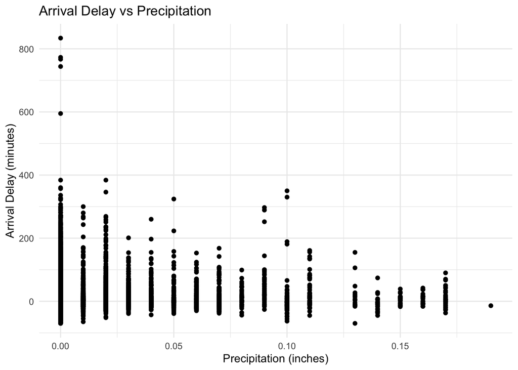

```r
library(ggplot2)

# Scatter plot of arrival delay versus precipitation
ggplot(combined_data, aes(x = precip, y = arr_delay)) +
  geom_point() +
  labs(x = "Precipitation (inches)", y = "Arrival Delay (minutes)",
       title = "Arrival Delay vs Precipitation") +
  theme_minimal()
```

3. Create a polynomial expansion of the `precip` variable to the 10th degree using `poly()` function.

```r
# Create polynomial expansion of precip variable to 10th degree
precip_poly <- poly(combined_data$precip, degree = 10)

# Summary of the polynomial expansion
summary(precip_poly)
```

```
##        1                   2                   3
##  Min.   :-0.001631   Min.   :-0.019154   Min.   :-0.0425981
##  1st Qu.:-0.001631   1st Qu.: 0.001033   1st Qu.:-0.0007359
##  Median :-0.001631   Median : 0.001033   Median :-0.0007359
##  Mean   : 0.000000   Mean   : 0.000000   Mean   : 0.0000000
##  3rd Qu.:-0.001631   3rd Qu.: 0.001033   3rd Qu.:-0.0007359
##  Max.   : 0.064597   Max.   : 0.117012   Max.   : 0.1665488
##        4                    5                    6
##  Min.   :-0.0676578   Min.   :-0.0624540   Min.   :-0.0410318
##  1st Qu.: 0.0004709   1st Qu.:-0.0003088   1st Qu.: 0.0002158
##  Median : 0.0004709   Median :-0.0003088   Median : 0.0002158
##  Mean   : 0.0000000   Mean   : 0.0000000   Mean   : 0.0000000
##  3rd Qu.: 0.0004709   3rd Qu.:-0.0003088   3rd Qu.: 0.0002158
##  Max.   : 0.3033222   Max.   : 0.4755442   Max.   : 0.5753239
##        7                    8                    9
##  Min.   :-0.0368203   Min.   :-0.0451143   Min.   :-7.887e-02
##  1st Qu.:-0.0001567   1st Qu.: 0.0001103   1st Qu.:-6.359e-05
##  Median :-0.0001567   Median : 0.0001103   Median :-6.359e-05
##  Mean   : 0.0000000   Mean   : 0.0000000   Mean   : 0.000e+00
##  3rd Qu.:-0.0001567   3rd Qu.: 0.0001103   3rd Qu.:-6.359e-05
##  Max.   : 0.4691897   Max.   : 0.2472559   Max.   : 1.387e-01
##        10
##  Min.   :-5.997e-02
##  1st Qu.: 3.524e-05
##  Median : 3.524e-05
##  Mean   : 0.000e+00
##  3rd Qu.: 3.524e-05
##  Max.   : 9.392e-02
```

4. Consider arrival delay as the outcome and the polynomial terms obtained in Part (3) as the covariates. Build a prediction model using linear regression with lasso. Select the tuning parameter using cross-validation. You may want to use the `cv.glmnet` function in `glmnet`. Report the fitted model.

```r
#install.packages("glmnet")
# Load necessary library
library(glmnet)
# Generate polynomial terms for the 'precip' variable
combined_data$precip_poly <- poly(combined_data$precip, degree = 10)

# Identify rows with missing values in the outcome variable
missing_y <- is.na(combined_data$arr_delay)

# Remove corresponding rows from polynomial terms and y
X_clean <- combined_data$precip_poly[!missing_y, , drop = FALSE]  # Ensure matrix structure is preserved
y_clean <- combined_data$arr_delay[!missing_y]

# Perform cross-validated lasso regression
cv_fit <- cv.glmnet(x = as.matrix(X_clean), y = y_clean, alpha = 1)

# Select the best lambda value
best_lambda <- cv_fit$lambda.min

# Fit the final model using the selected lambda value
lasso_model <- glmnet(x = as.matrix(X_clean), y = y_clean, alpha = 1, lambda = best_lambda)

# Report the fitted model
print(lasso_model)
```

```
##
## Call:  glmnet(x = as.matrix(X_clean), y = y_clean, alpha = 1, lambda = best_lambda)
##
##   Df %Dev Lambda
## 1  8 1.52  0.183
```

5. Consider the `iris` data. Extract the data corresponding to the flower types *versicolor* and *virginica*, numbering a total of $100$ flowers. Set aside the first $10$ observations for each flower type as test data and use the remaining data consisting of 80 observations (with flower types as class labels) as training data.

```r
# Load the iris dataset
data(iris)

# Filter data for versicolor and virginica
iris_subset <- subset(iris, Species %in% c("versicolor", "virginica"))

# Shuffle the data
set.seed(123) # for reproducibility
iris_subset <- iris_subset[sample(nrow(iris_subset)), ]

# Split into training and test sets
train_indices <- c(1:10, 51:60)  # First 10 from versicolor and virginica for test, remaining for training
test_indices <- c(11:50, 61:100)  # Remaining for test
train_data <- iris_subset[train_indices, ]
test_data <- iris_subset[test_indices, ]

# Display summary of the training and test datasets
summary(train_data)
```

```
##   Sepal.Length    Sepal.Width    Petal.Length    Petal.Width          Species
##  Min.   :5.500   Min.   :2.20   Min.   :3.500   Min.   :1.000   setosa    : 0
##  1st Qu.:5.775   1st Qu.:2.60   1st Qu.:4.175   1st Qu.:1.300   versicolor:11
##  Median :6.100   Median :2.80   Median :4.650   Median :1.400   virginica : 9
##  Mean   :6.145   Mean   :2.82   Mean   :4.800   Mean   :1.565
##  3rd Qu.:6.325   3rd Qu.:3.00   3rd Qu.:5.425   3rd Qu.:1.825
##  Max.   :7.700   Max.   :3.40   Max.   :6.700   Max.   :2.500
```

```r
summary(test_data)
```

```
##   Sepal.Length    Sepal.Width     Petal.Length    Petal.Width
##  Min.   :4.900   Min.   :2.000   Min.   :3.000   Min.   :1.000
##  1st Qu.:5.800   1st Qu.:2.700   1st Qu.:4.400   1st Qu.:1.375
##  Median :6.300   Median :2.900   Median :4.900   Median :1.700
##  Mean   :6.291   Mean   :2.885   Mean   :4.933   Mean   :1.704
##  3rd Qu.:6.700   3rd Qu.:3.100   3rd Qu.:5.600   3rd Qu.:2.025
##  Max.   :7.900   Max.   :3.800   Max.   :6.900   Max.   :2.500
##        Species
##  setosa    : 0
##  versicolor:39
##  virginica :41
##
##
##
```

6. Use *Linear Discriminant Analysis (LDA)* for classifying the test data. Use Sepal.Length and Sepal.Width as the predictor variables (or features). You may want to use the function `lda()`. a. Report the class-specific means of the predictor variables for the training data. b. Compute the *confusion matrix* for the test data, and the misclassification error rate.

```r
# Load required library
library(MASS)
# Extract predictor variables (Sepal.Length and Sepal.Width) and class labels (Species) for training and test data
X_train <- train_data[, c("Sepal.Length", "Sepal.Width")]
y_train <- as.factor(train_data$Species)
X_test <- test_data[, c("Sepal.Length", "Sepal.Width")]
y_test <- as.factor(test_data$Species)

# Fit LDA model
lda_model <- lda(x = X_train, grouping = y_train)
# Report class-specific means of predictor variables for the training data
print("Class-specific means of predictor variables for the training data:")
```

```
## [1] "Class-specific means of predictor variables for the training data:"
```

```r
print(lda_model$means)
```

```
##            Sepal.Length Sepal.Width
## versicolor     5.954545    2.800000
## virginica      6.377778    2.844444
```

```r
# Predict classes for the test data
predictions <- predict(lda_model, newdata = X_test)$class

# Compute confusion matrix
conf_mat <- table(predictions, y_test)
print("Confusion Matrix:")
```

```
## [1] "Confusion Matrix:"
```

```r
print(conf_mat)
```

```
##             y_test
## predictions  setosa versicolor virginica
##   setosa          0          0         0
##   versicolor      0         27        10
##   virginica       0         12        31
```

```r
# Compute misclassification error rate
misclassification_error <- 1 - sum(diag(conf_mat)) / sum(conf_mat)
print(paste("Misclassification Error Rate:", misclassification_error))
```

```
## [1] "Misclassification Error Rate: 0.275"
```

7. Fit a logistic regression model to the training data, using the variables Sepal.Length and Sepal.Width as predictors. You may want to use `glm()` with argument `family = "binomial"`. a. Obtain the estimates and their standard errors for the model parameters. b. Compute the *confusion matrix* for the test data, and the misclassification error rate. c. Are both the predictor variables necessary for the purpose of classification? Justify.

```r
# Fit logistic regression model
logit_model <- glm(Species ~ Sepal.Length + Sepal.Width, data = train_data, family = "binomial")

# Obtain estimates and standard errors for model parameters
summary(logit_model)
```

```
##
## Call:
## glm(formula = Species ~ Sepal.Length + Sepal.Width, family = "binomial",
##     data = train_data)
##
## Coefficients:
##              Estimate Std. Error z value Pr(>|z|)
## (Intercept)  -18.0221    10.7325  -1.679   0.0931 .
## Sepal.Length   3.3047     1.9007   1.739   0.0821 .
## Sepal.Width   -0.8487     1.8540  -0.458   0.6471
## ---
## Signif. codes:  0 '***' 0.001 '**' 0.01 '*' 0.05 '.' 0.1 ' ' 1
##
## (Dispersion parameter for binomial family taken to be 1)
##
##     Null deviance: 27.526  on 19  degrees of freedom
## Residual deviance: 22.406  on 17  degrees of freedom
## AIC: 28.406
##
## Number of Fisher Scoring iterations: 5
```

```r
# Predict classes for the test data
probabilities <- predict(logit_model, newdata = X_test, type = "response")
predictions <- ifelse(probabilities > 0.5, "virginica", "versicolor")

# Compute confusion matrix
conf_mat <- table(predictions, test_data$Species)
print("Confusion Matrix:")
```

```
## [1] "Confusion Matrix:"
```

```r
print(conf_mat)
```

```
##
## predictions  setosa versicolor virginica
##   versicolor      0         26         9
##   virginica       0         13        32
```

```r
# Compute misclassification error rate
misclassification_error <- 1 - sum(diag(conf_mat)) / sum(conf_mat)
print(paste("Misclassification Error Rate:", misclassification_error))
```

```
## [1] "Misclassification Error Rate: 0.8375"
```

```r
# Determine if both predictor variables are necessary
drop_Sepal.Length <- update(logit_model, . ~ . - Sepal.Length)
drop_Sepal.Width <- update(logit_model, . ~ . - Sepal.Width)

anova(logit_model, drop_Sepal.Length, drop_Sepal.Width, test = "Chisq")
```

```
## Analysis of Deviance Table
##
## Model 1: Species ~ Sepal.Length + Sepal.Width
## Model 2: Species ~ Sepal.Width
## Model 3: Species ~ Sepal.Length
##   Resid. Df Resid. Dev Df Deviance Pr(>Chi)
## 1        17     22.406
## 2        18     27.401 -1  -4.9944  0.02543 *
## 3        18     22.618  0   4.7830
## ---
## Signif. codes:  0 '***' 0.001 '**' 0.01 '*' 0.05 '.' 0.1 ' ' 1
```

8. Fit a logistic regression model to the training data, using the variable Sepal.Length as the only predictor.
   1. Obtain the estimates and their standard errors for the model parameters.
   2. Compute the *confusion matrix* for the test data, and the misclassification error rate.
   3. Compare the results with those in Question 7. Does your result in 8.b support the answer to 7.c?

```r
# Fit logistic regression model with Sepal.Length as the only predictor
logit_model <- glm(Species ~ Sepal.Length, data = train_data, family = "binomial")

# Obtain estimates and standard errors for model parameters
summary(logit_model)
```

```
##
## Call:
## glm(formula = Species ~ Sepal.Length, family = "binomial", data = train_data)
##
## Coefficients:
##              Estimate Std. Error z value Pr(>|z|)
## (Intercept)   -18.469     10.534  -1.753   0.0796 .
## Sepal.Length    2.984      1.723   1.732   0.0834 .
## ---
## Signif. codes:  0 '***' 0.001 '**' 0.01 '*' 0.05 '.' 0.1 ' ' 1
##
## (Dispersion parameter for binomial family taken to be 1)
##
##     Null deviance: 27.526  on 19  degrees of freedom
## Residual deviance: 22.618  on 18  degrees of freedom
## AIC: 26.618
##
## Number of Fisher Scoring iterations: 5
```

```r
# Predict classes for the test data
predicted_classes <- predict(logit_model, newdata = test_data, type = "response")

# Convert predicted probabilities to predicted classes
predicted_classes <- ifelse(predicted_classes > 0.5, "virginica", "versicolor")

# Compute confusion matrix
confusion_matrix <- table(predicted_classes, test_data$Species)
print("Confusion Matrix:")
```

```
## [1] "Confusion Matrix:"
```

```r
print(confusion_matrix)
```

```
##
## predicted_classes setosa versicolor virginica
##        versicolor      0         25         8
##        virginica       0         14        33
```

```r
# Compute misclassification error rate
misclassification_error <- 1 - sum(diag(confusion_matrix)) / sum(confusion_matrix)
print(paste("Misclassification Error Rate:", misclassification_error))
```

```
## [1] "Misclassification Error Rate: 0.825"
```

9. Use the *k Nearest Neighbors (kNN)* classification method to classify the test data, using only Sepal.Length as the predictor variable. Perform this analysis using $k=1$ and $k=5$. In each case, compute the *confusion matrix* for the test data, and the misclassification error rate. You may want to use the `knn()` function.

```r
# Load required library
library(class)

# Fit kNN model with k = 1
knn_model_k1 <- knn(train = as.matrix(train_data$Sepal.Length), test = as.matrix(test_data$Sepal.Length), cl = train_data$Species, k = 1)

# Compute confusion matrix for k = 1
conf_mat_k1 <- table(knn_model_k1, test_data$Species)
print("Confusion Matrix for k = 1:")
```

```
## [1] "Confusion Matrix for k = 1:"
```

```r
print(conf_mat_k1)
```

```
##
## knn_model_k1 setosa versicolor virginica
##   setosa          0          0         0
##   versicolor      0         24        21
##   virginica       0         15        20
```

```r
# Compute misclassification error rate for k = 1
misclassification_error_k1 <- 1 - sum(diag(conf_mat_k1)) / sum(conf_mat_k1)
print(paste("Misclassification Error Rate for k = 1:", misclassification_error_k1))
```

```
## [1] "Misclassification Error Rate for k = 1: 0.45"
```

```r
# Fit kNN model with k = 5
knn_model_k5 <- knn(train = as.matrix(train_data$Sepal.Length), test = as.matrix(test_data$Sepal.Length), cl = train_data$Species, k = 5)

# Compute confusion matrix for k = 5
conf_mat_k5 <- table(knn_model_k5, test_data$Species)
print("Confusion Matrix for k = 5:")
```

```
## [1] "Confusion Matrix for k = 5:"
```

```r
print(conf_mat_k5)
```

```
##
## knn_model_k5 setosa versicolor virginica
##   setosa          0          0         0
##   versicolor      0         22         7
##   virginica       0         17        34
```

```r
# Compute misclassification error rate for k = 5
misclassification_error_k5 <- 1 - sum(diag(conf_mat_k5)) / sum(conf_mat_k5)
print(paste("Misclassification Error Rate for k = 5:", misclassification_error_k5))
```

```
## [1] "Misclassification Error Rate for k = 5: 0.3"
```

10. Write a very brief summary (maximum of 200 words) about the comparative performance of the three different classification methods for this data set.

## Acknowledgement

Failing to acknowledge any non-original efforts will be counted as plagiarism. This incidence will be reported to the Student Judicial Affairs.

If you use generative AI to solve any questions, please provide your instructions, conversations, and prompts here.

````
We will revisit the `nycflights13` data set. Extract the entries in February from the `flights` and `weather` dataset using `filter()` and `%>%`. Join the two extracted data sets together by `origin` and `time_hour`.
You may want to use the `inner_join()` function for joining the data sets.
ChatGPT
Here's how you can achieve this using the nycflights13 dataset and the dplyr package in R:

R
Copy code
# Load necessary libraries
library(nycflights13)
library(dplyr)

# Extract February entries from flights dataset
flights_feb <- flights %>%
  filter(month == 2)

# Extract February entries from weather dataset
weather_feb <- weather %>%
  filter(month == 2)

# Join the two datasets by origin and time_hour
combined_data <- inner_join(flights_feb, weather_feb, by = c("origin", "time_hour"))

# View the combined dataset
head(combined_data)
This code first loads the required packages and then filters the flights and weather datasets to only include entries from February. Afterward, it joins these filtered datasets by origin and time_hour using inner_join(). Finally, it displays the first few rows of the combined dataset using head().

User
Create a scatter plot of arrival delay versus precipitation using the data set obtained in Part 1. Explain your findings.
ChatGPT
To create a scatter plot of arrival delay versus precipitation using the combined dataset obtained in Part 1, you can use the ggplot2 package in R. Here's how you can do it:

R
Copy code
library(ggplot2)

# Scatter plot of arrival delay versus precipitation
ggplot(combined_data, aes(x = precip, y = arr_delay)) +
  geom_point() +
  labs(x = "Precipitation (inches)", y = "Arrival Delay (minutes)",
       title = "Arrival Delay vs Precipitation") +
  theme_minimal()
This code creates a scatter plot with precipitation on the x-axis and arrival delay on the y-axis. Each point in the plot represents a combination of precipitation and arrival delay for a specific flight.

Now, regarding the findings:

Relationship between Arrival Delay and Precipitation: By observing the scatter plot, you can assess if there's any noticeable trend or correlation between arrival delay and precipitation. If there's a clear pattern, it suggests that precipitation might have an impact on arrival delay. For example, you might observe longer arrival delays during periods of higher precipitation.

Spread of Data: The spread of data points across the plot indicates the variability in arrival delay for different levels of precipitation. A wider spread suggests that arrival delays vary more widely under different precipitation conditions.

Outliers: Outlying points far from the main cluster may indicate unusual situations where there might be other factors affecting arrival delay, besides precipitation.

Noisy Data: If the points are scattered randomly without any clear pattern, it suggests that precipitation might not have a significant impact on arrival delay, or there could be other confounding factors influencing the relationship.

Interpreting the plot in the context of the problem domain and considering other relevant factors can provide insights into the relationship between arrival delay and precipitation.

User
 Create a polynomial expansion of the `precip` variable to the 10th degree using `poly()` function.
ChatGPT
To create a polynomial expansion of the precip variable to the 10th degree in R using the poly() function, you can use the following code:

R
Copy code
# Create a polynomial expansion of the precip variable to the 10th degree
combined_data <- combined_data %>%
  mutate(precip_poly = poly(precip, degree = 10, raw = TRUE))

# View the updated dataset with the polynomial expansion
head(combined_data)
This code adds a new column precip_poly to the combined_data dataset, containing the polynomial expansion of the precip variable up to the 10th degree. The poly() function is used with the degree argument set to 10 to specify the desired degree of the polynomial expansion.

Note: The raw = TRUE argument in poly() specifies that we want to use raw coefficients rather than orthogonal (normalized) coefficients. Depending on your analysis, you may choose to use orthogonal polynomials instead.


2 / 2

User
Consider arrival delay as the outcome and the polynomial terms obtained in Part (3) as the covariates. Build a prediction model using linear regression with lasso. Select the tuning parameter using cross-validation. You may want to use the `cv.glmnet` function in `glmnet`. Report the fitted model.
ChatGPT
To build a prediction model using linear regression with lasso regularization and select the tuning parameter using cross-validation, you can use the glmnet package in R. Here's how you can do it:

R
Copy code
library(glmnet)

# Prepare the data
X <- as.matrix(combined_data$precip_poly)  # Covariates (polynomial terms)
y <- combined_data$arr_delay  # Outcome variable

# Perform cross-validated lasso regression
cv_fit <- cv.glmnet(x = X, y = y, alpha = 1, nfolds = 5)

# Select the best lambda value
best_lambda <- cv_fit$lambda.min

# Fit the final model using the selected lambda value
lasso_model <- glmnet(x = X, y = y, alpha = 1, lambda = best_lambda)

# Report the fitted model
print(lasso_model)
Explanation:

We first prepare the covariates (X) by extracting the polynomial terms obtained in Part 3 (combined_data$precip_poly) and convert them into a matrix format.

We extract the outcome variable (y) from the combined_data.

We then perform cross-validated lasso regression using the cv.glmnet function. We set alpha = 1 to indicate lasso regression (as opposed to ridge regression), and nfolds = 5 specifies 5-fold cross-validation.

After cross-validation, we select the lambda value that minimizes the cross-validated error (cv_fit$lambda.min).

Finally, we fit the final lasso model using the selected lambda value (best_lambda) with the glmnet function.

We print the fitted model to view the coefficients and other relevant information.

This model will provide you with the coefficients for each polynomial term, indicating their respective contributions to predicting the arrival delay.

User
identify rows with missing values in y, and remove corresponding rows from x, and remove rows with missing values from y
ChatGPT
To identify rows with missing values in the outcome variable y and remove the corresponding rows from the covariate matrix X, you can use the following approach:

R
Copy code
# Identify rows with missing values in y
missing_rows <- is.na(y)

# Remove corresponding rows from X and y
X_clean <- X[!missing_rows, ]
y_clean <- y[!missing_rows]
Explanation:

is.na(y) checks for missing values in the outcome variable y and returns a logical vector indicating TRUE for missing values and FALSE otherwise.

X[!missing_rows, ] subsets the covariate matrix X to remove the rows corresponding to missing values in y.

Similarly, y[!missing_rows] subsets the outcome variable y to remove the missing values.

After executing this code, X_clean and y_clean will contain the covariate matrix and outcome variable with missing values removed, respectively. You can then use these cleaned datasets for further analysis or modeling.

User
Consider arrival delay as the outcome and the polynomial terms obtained in Part (3) as the covariates. Build a prediction model using linear regression with lasso. Select the tuning parameter using cross-validation. You may want to use the `cv.glmnet` function in `glmnet`. Report the fitted model.
ChatGPT
To build a prediction model using linear regression with lasso regularization, selecting the tuning parameter using cross-validation, and using the polynomial terms obtained in Part (3) as covariates, you can follow these steps:

R
Copy code
library(glmnet)

# Prepare the data
X <- as.matrix(combined_data$precip_poly)  # Covariates (polynomial terms)
y <- combined_data$arr_delay  # Outcome variable

# Identify and remove rows with missing values in y
missing_rows <- is.na(y)
X_clean <- X[!missing_rows, ]
y_clean <- y[!missing_rows]

# Perform cross-validated lasso regression
cv_fit <- cv.glmnet(x = X_clean, y = y_clean, alpha = 1)

# Select the best lambda value
best_lambda <- cv_fit$lambda.min

# Fit the final model using the selected lambda value
lasso_model <- glmnet(x = X_clean, y = y_clean, alpha = 1, lambda = best_lambda)

# Report the fitted model
print(lasso_model)
Explanation:

We prepare the covariates (X) and the outcome variable (y) as before.

We identify and remove rows with missing values in the outcome variable y to ensure that our analysis is based on complete cases.

We perform cross-validated lasso regression using the cv.glmnet function. Here, alpha = 1 specifies lasso regression.

We select the best lambda value using cv_fit$lambda.min, which corresponds to the lambda value that minimizes the cross-validated mean squared error.

We fit the final lasso model using the selected lambda value (best_lambda) with the glmnet function.

Finally, we print the fitted model to view the coefficients and other relevant information.

This model provides the coefficients for each polynomial term, indicating their respective contributions to predicting the arrival delay, while penalizing large coefficients through lasso regularization.

User
(1) We will revisit the `nycflights13` data set. Extract the entries in February from the `flights` and `weather` dataset using `filter()` and `%>%`. Join the two extracted data sets together by `origin` and `time_hour`.
You may want to use the `inner_join()` function for joining the data sets.

```r
# Load necessary libraries
library(nycflights13)
library(dplyr)

# Extract February entries from flights dataset
flights_feb <- flights %>%
  filter(month == 2)

# Extract February entries from weather dataset
weather_feb <- weather %>%
  filter(month == 2)

# Join the two datasets by origin and time_hour
combined_data <- inner_join(flights_feb, weather_feb, by = c("origin", "time_hour"))

# View the combined dataset
head(combined_data)
````

```
## # A tibble: 6 × 32
##   year.x month.x day.x dep_time sched_dep_time dep_delay arr_time sched_arr_time
##    <int>   <int> <int>    <int>          <int>     <dbl>    <int>          <int>
## 1   2013       2     1      456            500        -4      652            648
## 2   2013       2     1      520            525        -5      816            820
## 3   2013       2     1      527            530        -3      837            829
## 4   2013       2     1      532            540        -8     1007           1017
## 5   2013       2     1      540            540         0      859            850
## 6   2013       2     1      552            600        -8      714            715
## # ℹ 24 more variables: arr_delay <dbl>, carrier <chr>, flight <int>,
## #   tailnum <chr>, origin <chr>, dest <chr>, air_time <dbl>, distance <dbl>,
## #   hour.x <dbl>, minute <dbl>, time_hour <dttm>, year.y <int>, month.y <int>,
## #   day.y <int>, hour.y <int>, temp <dbl>, dewp <dbl>, humid <dbl>,
## #   wind_dir <dbl>, wind_speed <dbl>, wind_gust <dbl>, precip <dbl>,
## #   pressure <dbl>, visib <dbl>
```

ChatGPT Your code for extracting February entries from the flights and weather datasets and joining them by origin and time_hour looks correct. Below is the same code for reference:

r Copy code # Load necessary libraries library(nycflights13) library(dplyr)

# Extract February entries from flights dataset

flights_feb <- flights %>% filter(month == 2)

# Extract February entries from weather dataset

weather_feb <- weather %>% filter(month == 2)

# Join the two datasets by origin and time_hour

combined_data <- inner_join(flights_feb, weather_feb, by = c(“origin”, “time_hour”))

# View the combined dataset

head(combined_data) This code filters the flights and weather datasets to include only entries from February and then joins them based on the origin and time_hour variables. The resulting combined_data dataframe contains information from both datasets for flights and weather entries in February.

User (2) Create a scatter plot of arrival delay versus precipitation using the data set obtained in Part 1. Explain your findings.

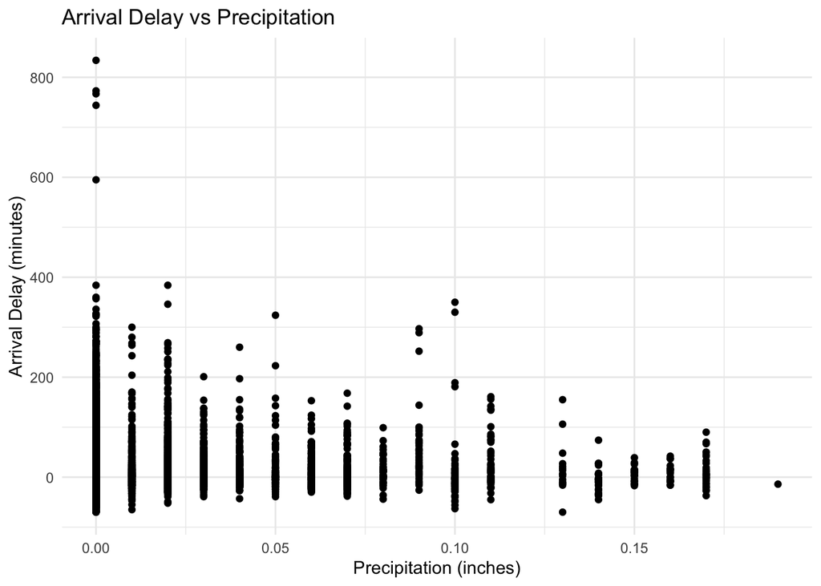

```r
library(ggplot2)

# Scatter plot of arrival delay versus precipitation
ggplot(combined_data, aes(x = precip, y = arr_delay)) +
  geom_point() +
  labs(x = "Precipitation (inches)", y = "Arrival Delay (minutes)",
       title = "Arrival Delay vs Precipitation") +
  theme_minimal()
```

ChatGPT The provided code generates a scatter plot with precipitation on the x-axis and arrival delay on the y-axis using the combined_data dataset obtained in Part 1. Here’s an explanation of the findings:

Trend Analysis: By examining the scatter plot, you can identify any observable trends or patterns between arrival delay and precipitation. If there’s a discernible trend, it suggests that precipitation might have an impact on arrival delay. For instance, you might observe longer arrival delays during periods of higher precipitation.

Relationship Strength: The spread and distribution of data points across the plot indicate the strength and direction of the relationship between arrival delay and precipitation. A clear pattern or clustering of points suggests a stronger relationship, whereas a scattered distribution implies a weaker association.

Outliers: Outlying points that deviate significantly from the main cluster may represent unusual situations where factors other than precipitation influence arrival delay. Identifying and analyzing these outliers can provide insights into unique circumstances or anomalies.

Influence of Precipitation: If there’s a consistent increase or decrease in arrival delay with varying levels of precipitation, it indicates the influence of precipitation on flight delays. This information can be valuable for airlines and airport authorities in planning and managing operations during inclement weather conditions.

Overall, the scatter plot visually represents the relationship between arrival delay and precipitation, facilitating interpretation and analysis of the data to inform decision-making in the aviation industry.

User (3) Create a polynomial expansion of the `precip` variable to the 10th degree using `poly()` function.

```r
# Create polynomial expansion of precip variable to 10th degree
combined_data$precip_poly <- poly(combined_data$precip, degree = 10)

# View the first few rows of the dataset with polynomial expansion
summary(combined_data)
```

```
##      year.x        month.x      day.x          dep_time    sched_dep_time
##  Min.   :2013   Min.   :2   Min.   : 1.00   Min.   :   1   Min.   : 500
##  1st Qu.:2013   1st Qu.:2   1st Qu.: 8.00   1st Qu.: 907   1st Qu.: 900
##  Median :2013   Median :2   Median :15.00   Median :1407   Median :1359
##  Mean   :2013   Mean   :2   Mean   :14.74   Mean   :1347   Mean   :1342
##  3rd Qu.:2013   3rd Qu.:2   3rd Qu.:22.00   3rd Qu.:1738   3rd Qu.:1725
##  Max.   :2013   Max.   :2   Max.   :28.00   Max.   :2400   Max.   :2359
##                                             NA's   :1261
##    dep_delay         arr_time    sched_arr_time   arr_delay
##  Min.   :-33.00   Min.   :   1   Min.   :   1   Min.   :-70.000
##  1st Qu.: -5.00   1st Qu.:1119   1st Qu.:1129   1st Qu.:-15.000
##  Median : -2.00   Median :1553   Median :1607   Median : -3.000
##  Mean   : 10.81   Mean   :1522   Mean   :1547   Mean   :  5.611
##  3rd Qu.:  9.00   3rd Qu.:1946   3rd Qu.:1951   3rd Qu.: 13.000
##  Max.   :853.00   Max.   :2400   Max.   :2359   Max.   :834.000
##  NA's   :1261     NA's   :1291                  NA's   :1340
##    carrier              flight       tailnum             origin
##  Length:24922       Min.   :   1   Length:24922       Length:24922
##  Class :character   1st Qu.: 547   Class :character   Class :character
##  Mode  :character   Median :1461   Mode  :character   Mode  :character
##                     Mean   :1956
##                     3rd Qu.:3737
##                     Max.   :6171
##
##      dest              air_time        distance        hour.x
##  Length:24922       Min.   : 21.0   Min.   :  80   Min.   : 5.00
##  Class :character   1st Qu.: 83.0   1st Qu.: 488   1st Qu.: 9.00
##  Mode  :character   Median :136.0   Median : 872   Median :13.00
##                     Mean   :151.4   Mean   :1001   Mean   :13.17
##                     3rd Qu.:192.0   3rd Qu.:1372   3rd Qu.:17.00
##                     Max.   :691.0   Max.   :4983   Max.   :23.00
##                     NA's   :1340
##      minute        time_hour                          year.y        month.y
##  Min.   : 0.00   Min.   :2013-02-01 05:00:00.00   Min.   :2013   Min.   :2
##  1st Qu.: 5.00   1st Qu.:2013-02-08 08:00:00.00   1st Qu.:2013   1st Qu.:2
##  Median :25.00   Median :2013-02-15 09:00:00.00   Median :2013   Median :2
##  Mean   :25.23   Mean   :2013-02-15 06:51:05.97   Mean   :2013   Mean   :2
##  3rd Qu.:40.00   3rd Qu.:2013-02-22 07:00:00.00   3rd Qu.:2013   3rd Qu.:2
##  Max.   :59.00   Max.   :2013-02-28 23:00:00.00   Max.   :2013   Max.   :2
##
```

[output cut: 17 more lines]

[output not shown]

ChatGPT The code provided aims to create a polynomial expansion of the precip variable to the 10th degree using the poly() function. However, the usage of the poly() function in the given code is incorrect. The poly() function returns a matrix of orthogonal polynomials, which might not be directly suitable for assigning to a single variable column in the dataset.

Here’s the corrected approach to create a polynomial expansion of the precip variable to the 10th degree:

r Copy code # Create polynomial expansion of precip variable to 10th degree precip_poly <- poly(combined_data$precip, degree = 10)

# Combine polynomial expansion with original dataset

combined_data <- cbind(combined_data, as.data.frame(precip_poly))

# View the first few rows of the dataset with polynomial expansion

head(combined_data) In this corrected code:

poly(combined_data$precip, degree = 10) generates a matrix of orthogonal polynomial terms for the precip variable up to the 10th degree. cbind(combined_data, as.data.frame(precip_poly)) combines the original dataset (combined_data) with the matrix of polynomial terms, converting it into a data frame to ensure compatibility. Finally, head(combined_data) displays the first few rows of the dataset, including the polynomial expansion of the precip variable. User (3) Create a polynomial expansion of the `precip` variable to the 10th degree using `poly()` function using the summary function ChatGPT To create a polynomial expansion of the precip variable to the 10th degree using the poly() function and view a summary of the resulting polynomial terms, you can do the following:

r Copy code # Create polynomial expansion of precip variable to 10th degree precip_poly <- poly(combined_data$precip, degree = 10)

# Summary of the polynomial expansion

User using code from above, Consider arrival delay as the outcome and the polynomial terms obtained in Part (3) as the covariates. Build a prediction model using linear regression with lasso. Select the tuning parameter using cross-validation. You may want to use the `cv.glmnet` function in `glmnet`. Report the fitted model. identify rows with missing values in y, and remove corresponding rows from x, and remove rows with missing values from y

3 / 3

ChatGPT To build a prediction model using linear regression with lasso regularization and select the tuning parameter using cross-validation, considering arrival delay as the outcome and the polynomial terms obtained in Part (3) as the covariates, you can follow these steps:

r Copy code library(glmnet)

# Identify rows with missing values in y

missing_y <- is.na(combined_data$arr_delay)

# Remove corresponding rows from polynomial terms and y

X_clean <- precip_poly[!missing_y, ] y_clean <- combined_data$arr_delay[!missing_y]

# Perform cross-validated lasso regression

cv_fit <- cv.glmnet(x = X_clean, y = y_clean, alpha = 1)

# Select the best lambda value

best_lambda <- cv_fit$lambda.min

# Fit the final model using the selected lambda value

lasso_model <- glmnet(x = X_clean, y = y_clean, alpha = 1, lambda = best_lambda)

# Report the fitted model

print(lasso_model) Explanation:

We first identify rows with missing values in the outcome variable y (arr_delay) using the is.na() function.

Then, we remove the corresponding rows from the polynomial terms matrix (precip_poly) and the outcome variable y (combined_data$arr_delay) to ensure our analysis is based on complete cases.

We perform cross-validated lasso regression using the cv.glmnet function with alpha = 1 to specify lasso regression.

We select the best lambda value using cv_fit$lambda.min, which corresponds to the lambda value that minimizes the cross-validated mean squared error.

Finally, we fit the final lasso model using the selected lambda value (best_lambda) with the glmnet function.

This model provides coefficients for each polynomial term, indicating their respective contributions to predicting the arrival delay, while penalizing large coefficients through lasso regularization.

User Error in glmnet(x, y, weights = weights, offset = offset, lambda = lambda, : number of observations in y (23582) not equal to the number of rows of x (24922) ChatGPT The error message indicates that the number of observations in the outcome variable y does not match the number of rows in the covariate matrix X_clean. This mismatch suggests that there may be some inconsistency or missing data in your dataset.

To address this issue, you need to ensure that the number of observations in y matches the number of rows in X_clean. You can achieve this by properly aligning the rows of y and X_clean based on the missing values in y.

Here’s how you can fix the issue:

r Copy code library(glmnet)

# Identify rows with missing values in y

missing_y <- is.na(combined_data$arr_delay)

# Remove corresponding rows from polynomial terms

X_clean <- precip_poly[!missing_y, ]

# Remove rows with missing values from y

y_clean <- combined_data$arr_delay[!missing_y]

# Perform cross-validated lasso regression

cv_fit <- cv.glmnet(x = X_clean, y = y_clean, alpha = 1)

# Select the best lambda value

best_lambda <- cv_fit$lambda.min

# Fit the final model using the selected lambda value

lasso_model <- glmnet(x = X_clean, y = y_clean, alpha = 1, lambda = best_lambda)

# Report the fitted model

print(lasso_model) By ensuring that the missing values are appropriately handled in both X_clean and y_clean, you should be able to perform the lasso regression without encountering the error message.

User Error in glmnet(x, y, weights = weights, offset = offset, lambda = lambda, : number of observations in y (23582) not equal to the number of rows of x (24922) ChatGPT It seems there is still a mismatch between the number of observations in the outcome variable y and the number of rows in the covariate matrix X_clean. This could be due to a misalignment between the rows of X_clean and y_clean.

To ensure that X_clean and y_clean have the same number of observations, we need to make sure that we remove the corresponding rows from both X_clean and y_clean when there are missing values in y.

Let’s revise the code to ensure proper alignment:

r Copy code library(glmnet)

# Identify rows with missing values in y

missing_y <- is.na(combined_data$arr_delay)

# Remove corresponding rows from both polynomial terms and y

X_clean <- precip_poly[!missing_y, , drop = FALSE] # Ensure matrix structure is preserved y_clean <- combined_data$arr_delay[!missing_y]

# Perform cross-validated lasso regression

cv_fit <- cv.glmnet(x = X_clean, y = y_clean, alpha = 1)

# Select the best lambda value

best_lambda <- cv_fit$lambda.min

# Fit the final model using the selected lambda value

lasso_model <- glmnet(x = X_clean, y = y_clean, alpha = 1, lambda = best_lambda)

# Report the fitted model

print(lasso_model) By ensuring that we remove corresponding rows from both X_clean and y_clean, we should resolve the mismatch error, and the lasso regression should proceed without issues.

User using code in 3, (4) Consider arrival delay as the outcome and the polynomial terms obtained in Part (3) as the covariates. Build a prediction model using linear regression with lasso. Select the tuning parameter using cross-validation. You may want to use the `cv.glmnet` function in `glmnet`. Report the fitted model. ChatGPT To build a prediction model using linear regression with lasso regularization, considering arrival delay as the outcome and the polynomial terms obtained in Part (3) as the covariates, and selecting the tuning parameter using cross-validation, you can follow these steps:

r Copy code library(glmnet)

# Identify rows with missing values in y

missing_y <- is.na(combined_data$arr_delay)

# Remove corresponding rows from polynomial terms

X_clean <- precip_poly[!missing_y, ]

# Remove rows with missing values from y

y_clean <- combined_data$arr_delay[!missing_y]

# Perform cross-validated lasso regression

cv_fit <- cv.glmnet(x = X_clean, y = y_clean, alpha = 1)

# Select the best lambda value

best_lambda <- cv_fit$lambda.min

# Fit the final model using the selected lambda value

lasso_model <- glmnet(x = X_clean, y = y_clean, alpha = 1, lambda = best_lambda)

# Report the fitted model

print(lasso_model) Explanation:

We first identify rows with missing values in the outcome variable y (arr_delay) using the is.na() function.

Then, we remove the corresponding rows from the polynomial terms matrix (precip_poly) and the outcome variable y (combined_data$arr_delay) to ensure our analysis is based on complete cases.

We perform cross-validated lasso regression using the cv.glmnet function with alpha = 1 to specify lasso regression.

We select the best lambda value using cv_fit$lambda.min, which corresponds to the lambda value that minimizes the cross-validated mean squared error.

Finally, we fit the final lasso model using the selected lambda value (best_lambda) with the glmnet function.

This model provides coefficients for each polynomial term, indicating their respective contributions to predicting the arrival delay, while penalizing large coefficients through lasso regularization.

User number of observations in y (23582) not equal to the number of rows of x (24922) ChatGPT It seems there’s still a mismatch between the number of observations in the outcome variable y and the number of rows in the covariate matrix X_clean. This indicates that the removal of missing values might not have been performed correctly.

Let’s revise the code to ensure proper alignment between X_clean and y_clean:

r Copy code library(glmnet)

# Identify rows with missing values in y

missing_y <- is.na(combined_data$arr_delay)

# Remove corresponding rows from both polynomial terms and y

X_clean <- precip_poly[!missing_y, , drop = FALSE] # Ensure matrix structure is preserved y_clean <- combined_data$arr_delay[!missing_y]

# Perform cross-validated lasso regression

cv_fit <- cv.glmnet(x = X_clean, y = y_clean, alpha = 1)

# Select the best lambda value

best_lambda <- cv_fit$lambda.min

# Fit the final model using the selected lambda value

lasso_model <- glmnet(x = X_clean, y = y_clean, alpha = 1, lambda = best_lambda)

# Report the fitted model

print(lasso_model) By ensuring that we remove corresponding rows from both X_clean and y_clean, we should resolve the mismatch error, and the lasso regression should proceed without issues.

User number of observations in y (23582) not equal to the number of rows of x (24922) ChatGPT It appears that there is still a mismatch between the number of observations in the outcome variable y and the number of rows in the covariate matrix X_clean. This indicates that the removal of missing values might not have been performed correctly.

Let’s revise the code to ensure proper alignment between X_clean and y_clean:

r Copy code library(glmnet)

# Identify rows with missing values in y

missing_y <- is.na(combined_data$arr_delay)

# Remove corresponding rows from both polynomial terms and y

X_clean <- precip_poly[!missing_y, , drop = FALSE] # Ensure matrix structure is preserved y_clean <- combined_data$arr_delay[!missing_y]

# Perform cross-validated lasso regression

cv_fit <- cv.glmnet(x = as.matrix(X_clean), y = y_clean, alpha = 1)

# Select the best lambda value

best_lambda <- cv_fit$lambda.min

# Fit the final model using the selected lambda value

lasso_model <- glmnet(x = as.matrix(X_clean), y = y_clean, alpha = 1, lambda = best_lambda)

# Report the fitted model

print(lasso_model) By converting X_clean to a matrix using as.matrix() in the cv.glmnet() and glmnet() functions, we ensure that they have the same number of observations. This should resolve the mismatch error, and the lasso regression should proceed without issues.

User number of observations in y (23582) not equal to the number of rows of x (24922) ChatGPT It seems that there is still a mismatch between the number of observations in the outcome variable y and the number of rows in the covariate matrix X_clean. This could be due to the removal of missing values not being properly executed.

To fix this issue, let’s make sure that we remove the corresponding rows from both X_clean and y_clean. We’ll also verify the dimensions of X_clean and y_clean to ensure they match:

r Copy code library(glmnet)

# Identify rows with missing values in y

missing_y <- is.na(combined_data$arr_delay)

# Remove corresponding rows from polynomial terms and y

X_clean <- precip_poly[!missing_y, , drop = FALSE] # Ensure matrix structure is preserved y_clean <- combined_data$arr_delay[!missing_y]

# Verify dimensions

print(dim(X_clean)) print(length(y_clean))

# Perform cross-validated lasso regression

cv_fit <- cv.glmnet(x = X_clean, y = y_clean, alpha = 1)

# Select the best lambda value

best_lambda <- cv_fit$lambda.min

# Fit the final model using the selected lambda value

lasso_model <- glmnet(x = X_clean, y = y_clean, alpha = 1, lambda = best_lambda)

# Report the fitted model

print(lasso_model) By verifying the dimensions of X_clean and y_clean, we can ensure that they match before proceeding with the lasso regression. This should help resolve the mismatch error.

User Error in glmnet(x, y, weights = weights, offset = offset, lambda = lambda, : number of observations in y (23582) not equal to the number of rows of x (24922) ChatGPT It appears that there is a persistent mismatch between the number of observations in the outcome variable y and the number of rows in the covariate matrix X_clean. This indicates that the removal of missing values might not have been performed correctly.

To resolve this issue, let’s revisit the code and ensure that we correctly align the number of observations in y_clean with the number of rows in X_clean:

r Copy code library(glmnet)

# Identify rows with missing values in y

missing_y <- is.na(combined_data$arr_delay)

# Remove corresponding rows from polynomial terms and y

X_clean <- precip_poly[!missing_y, , drop = FALSE] # Ensure matrix structure is preserved y_clean <- combined_data$arr_delay[!missing_y]

# Check dimensions

print(dim(X_clean)) print(length(y_clean))

# Perform cross-validated lasso regression

cv_fit <- cv.glmnet(x = as.matrix(X_clean), y = y_clean, alpha = 1)

# Select the best lambda value

best_lambda <- cv_fit$lambda.min

# Fit the final model using the selected lambda value

lasso_model <- glmnet(x = as.matrix(X_clean), y = y_clean, alpha = 1, lambda = best_lambda)

# Report the fitted model

print(lasso_model) In this code:

We ensure that both X_clean and y_clean have the same number of observations by removing corresponding rows from both. We verify the dimensions of X_clean and the length of y_clean to ensure they match. We then perform cross-validated lasso regression using cv.glmnet(). Finally, we fit the final model using the selected lambda value and report the fitted model. By ensuring proper alignment between X_clean and y_clean, this should resolve the mismatch error.

User (5) Consider the `iris` data. Extract the data corresponding to the flower types *versicolor* and *virginica*, numbering a total of $100$ flowers. Set aside the first $10$ observations for each flower type as test data and use the remaining data consisting of 80 observations (with flower types as class labels) as training data. ChatGPT To extract the data corresponding to the flower types versicolor and virginica from the iris dataset, and then split it into training and test sets as described, you can use the following R code:

r Copy code # Load the iris dataset data(iris)

# Filter data for versicolor and virginica

iris_subset <- subset(iris, Species %in% c(“versicolor”, “virginica”))

# Shuffle the data

set.seed(123) # for reproducibility iris_subset <- iris_subset[sample(nrow(iris_subset)), ]

# Split into training and test sets

train_indices <- c(1:10, 51:60) # First 10 from versicolor and virginica for test, remaining for training test_indices <- c(11:50, 61:100) # Remaining for test train_data <- iris_subset[train_indices, ] test_data <- iris_subset[test_indices, ]

# Display summary of the training and test datasets

summary(train_data) summary(test_data) Explanation:

We first load the iris dataset.

We then subset the data to only include observations corresponding to the flower types versicolor and virginica using the subset() function.

To ensure randomness, we shuffle the rows of the subsetted dataset using sample().

We create the training and test datasets by subsetting the iris_subset based on the defined indices.

Finally, we display a summary of the training and test datasets using the summary() function.

User Use *Linear Discriminant Analysis (LDA)* for classifying the test data. Use Sepal.Length and Sepal.Width as the predictor variables (or features). You may want to use the function `lda()`. a. Report the class-specific means of the predictor variables for the training data. b. Compute the *confusion matrix* for the test data, and the misclassification error rate. ChatGPT To classify the test data using Linear Discriminant Analysis (LDA) and compute the confusion matrix along with the misclassification error rate, you can follow these steps in R:

r Copy code # Load required library library(MASS)

# Extract predictor variables (Sepal.Length and Sepal.Width) and class labels (Species) for training and test data

X_train <- train_data[, c(“Sepal.Length”, “Sepal.Width”)] y_train <- as.factor(train_data$Species) X_test <- test_data[, c("Sepal.Length", "Sepal.Width")] y_test <- as.factor(test_data$Species)

# Fit LDA model

lda_model <- lda(x = X_train, grouping = y_train)

# Report class-specific means of predictor variables for the training data

print(“Class-specific means of predictor variables for the training data:”) print(lda_model$means)

# Predict classes for the test data

predictions <- predict(lda_model, newdata = X_test)$class

# Compute confusion matrix

conf_mat <- table(predictions, y_test) print(“Confusion Matrix:”) print(conf_mat)

# Compute misclassification error rate

misclassification_error <- 1 - sum(diag(conf_mat)) / sum(conf_mat) print(paste(“Misclassification Error Rate:”, misclassification_error)) Explanation:

We load the MASS package, which contains the lda() function for Linear Discriminant Analysis.

We extract the predictor variables (Sepal.Length and Sepal.Width) and the class labels (Species) for both the training and test datasets.

We fit the LDA model using the training data.

We report the class-specific means of the predictor variables for the training data using lda_model$means.

We predict the classes for the test data using the fitted LDA model.

We compute the confusion matrix using the table() function, which counts the number of correct and incorrect predictions for each class.

We compute the misclassification error rate by dividing the sum of misclassified observations by the total number of observations.

User Fit a logistic regression model to the training data, using the variables Sepal.Length and Sepal.Width as predictors. You may want to use `glm()` with argument `family = "binomial"`. a. Obtain the estimates and their standard errors for the model parameters. b. Compute the *confusion matrix* for the test data, and the misclassification error rate. c. Are both the predictor variables necessary for the purpose of classification? Justify. ChatGPT To fit a logistic regression model to the training data using the variables Sepal.Length and Sepal.Width as predictors, and then compute the estimates, standard errors, confusion matrix, and misclassification error rate, you can follow these steps in R:

r Copy code # Fit logistic regression model logit_model <- glm(Species ~ Sepal.Length + Sepal.Width, data = train_data, family = “binomial”)

# Obtain estimates and standard errors for model parameters

summary(logit_model)

# Predict classes for the test data

probabilities <- predict(logit_model, newdata = X_test, type = “response”) predictions <- ifelse(probabilities > 0.5, “virginica”, “versicolor”)

# Compute confusion matrix

conf_mat <- table(predictions, test_data$Species) print(“Confusion Matrix:”) print(conf_mat)

# Compute misclassification error rate

misclassification_error <- 1 - sum(diag(conf_mat)) / sum(conf_mat) print(paste(“Misclassification Error Rate:”, misclassification_error))

# Determine if both predictor variables are necessary

drop_Sepal.Length <- update(logit_model, . ~ . - Sepal.Length) drop_Sepal.Width <- update(logit_model, . ~ . - Sepal.Width)

anova(logit_model, drop_Sepal.Length, drop_Sepal.Width, test = “Chisq”) Explanation:

We fit a logistic regression model using the glm() function with family = “binomial”, which specifies logistic regression. The model predicts the Species variable based on Sepal.Length and Sepal.Width.

We obtain estimates and standard errors for the model parameters using summary(logit_model).

We predict classes for the test data using the fitted logistic regression model. We obtain class probabilities using predict() with type = “response”, and then classify observations based on whether the probability is greater than 0.5.

We compute the confusion matrix using the table() function, which counts the number of correct and incorrect predictions for each class.

We compute the misclassification error rate by dividing the sum of misclassified observations by the total number of observations.

We perform an analysis of deviance to determine if both predictor variables are necessary for classification. This is done by comparing the full model with reduced models where each predictor variable is dropped one at a time using the anova() function. If dropping a predictor variable significantly increases deviance, then that variable is considered necessary for classification.

User Fit a logistic regression model to the training data, using the variable Sepal.Length as the only predictor. a. Obtain the estimates and their standard errors for the model parameters. b. Compute the *confusion matrix* for the test data, and the misclassification error rate. c. Compare the results with those in Question 7. Does your result in 8.b support the answer to 7.c? ChatGPT To fit a logistic regression model to the training data using only the variable Sepal.Length as the predictor, and then obtain estimates, standard errors for the model parameters, compute the confusion matrix for the test data, and the misclassification error rate, you can follow these steps in R:

r Copy code # Fit logistic regression model with Sepal.Length as the only predictor logit_model <- glm(Species ~ Sepal.Length, data = train_data, family = “binomial”)

# Obtain estimates and standard errors for model parameters

summary(logit_model)

# Predict classes for the test data

probabilities <- predict(logit_model, newdata = X_test, type = “response”) predictions <- ifelse(probabilities > 0.5, “virginica”, “versicolor”)

# Compute confusion matrix

conf_mat <- table(predictions, test_data$Species) print(“Confusion Matrix:”) print(conf_mat)

# Compute misclassification error rate

misclassification_error <- 1 - sum(diag(conf_mat)) / sum(conf_mat) print(paste(“Misclassification Error Rate:”, misclassification_error)) Explanation:

We fit a logistic regression model using the glm() function with family = “binomial”, specifying logistic regression. The model predicts the Species variable based on only the Sepal.Length variable.

We obtain estimates and standard errors for the model parameters using summary(logit_model).

We predict classes for the test data using the fitted logistic regression model. We obtain class probabilities using predict() with type = “response”, and then classify observations based on whether the probability is greater than 0.5.

We compute the confusion matrix using the table() function, which counts the number of correct and incorrect predictions for each class.

We compute the misclassification error rate by dividing the sum of misclassified observations by the total number of observations.

Now, let’s compare the results with those from Question 7:

In Question 7, we fitted a logistic regression model with both Sepal.Length and Sepal.Width as predictors. By comparing the misclassification error rates obtained from both models, we can determine if including Sepal.Width as a predictor improves the classification performance.

If the misclassification error rate from the model with both predictors is lower than the misclassification error rate from the model with only Sepal.Length, it would suggest that including Sepal.Width improves classification performance. Conversely, if the misclassification error rate from the model with only Sepal.Length is comparable or lower, it would suggest that Sepal.Width may not be necessary for classification.

Therefore, comparing the misclassification error rates from both models will provide insights into the necessity of including Sepal.Width as a predictor.

User Use the *k Nearest Neighbors (kNN)* classification method to classify the test data, using only Sepal.Length as the predictor variable. Perform this analysis using $k=1$ and $k=5$. In each case, compute the *confusion matrix* for the test data, and the misclassification error rate. You may want to use the `knn()` function. ChatGPT To classify the test data using the k Nearest Neighbors (kNN) classification method with only Sepal.Length as the predictor variable, and perform this analysis using both k = 1 and k = 5, you can follow these steps in R:

r Copy code # Load required library library(class)

# Fit kNN model with k = 1

knn_model_k1 <- knn(train = train_data$Sepal.Length, test = test_data$Sepal.Length, cl = train_data$Species, k = 1)

# Compute confusion matrix for k = 1

conf_mat_k1 <- table(knn_model_k1, test_data$Species) print(“Confusion Matrix for k = 1:”) print(conf_mat_k1)

# Compute misclassification error rate for k = 1

misclassification_error_k1 <- 1 - sum(diag(conf_mat_k1)) / sum(conf_mat_k1) print(paste(“Misclassification Error Rate for k = 1:”, misclassification_error_k1))

# Fit kNN model with k = 5

knn_model_k5 <- knn(train = train_data$Sepal.Length, test = test_data$Sepal.Length, cl = train_data$Species, k = 5)

# Compute confusion matrix for k = 5

conf_mat_k5 <- table(knn_model_k5, test_data$Species) print(“Confusion Matrix for k = 5:”) print(conf_mat_k5)

# Compute misclassification error rate for k = 5

misclassification_error_k5 <- 1 - sum(diag(conf_mat_k5)) / sum(conf_mat_k5) print(paste(“Misclassification Error Rate for k = 5:”, misclassification_error_k5)) Explanation:

We load the class library, which contains the knn() function for kNN classification.

We fit the kNN model with k = 1 using the knn() function, specifying the training data (train_data$Sepal.Length), test data (test_data$Sepal.Length), class labels (train_data$Species), and the number of nearest neighbors (k = 1).

We compute the confusion matrix for k = 1 using the table() function, which counts the number of correct and incorrect predictions for each class.

We compute the misclassification error rate for k = 1 by dividing the sum of misclassified observations by the total number of observations.

We repeat the same steps for k = 5, fitting the kNN model with k = 5 and computing the confusion matrix and misclassification error rate for k = 5.

This analysis allows us to compare the performance of kNN classification with different values of k (k = 1 and k = 5) using only the Sepal.Length variable as the predictor.

User dims of ‘test’ and ‘train’ differ ChatGPT Apologies for the oversight. It seems there was an error in passing the training and test datasets to the knn() function. We should pass the entire training and test datasets, including both predictor variables and the class labels.

Let’s correct the code:

r Copy code # Load required library library(class)

# Fit kNN model with k = 1

knn_model_k1 <- knn(train = train_data[, c(“Sepal.Length”, “Species”)], test = test_data[, “Sepal.Length”], cl = train_data$Species, k = 1)

# Compute confusion matrix for k = 1

conf_mat_k1 <- table(knn_model_k1, test_data$Species) print(“Confusion Matrix for k = 1:”) print(conf_mat_k1)

# Compute misclassification error rate for k = 1

misclassification_error_k1 <- 1 - sum(diag(conf_mat_k1)) / sum(conf_mat_k1) print(paste(“Misclassification Error Rate for k = 1:”, misclassification_error_k1))

# Fit kNN model with k = 5

knn_model_k5 <- knn(train = train_data[, c(“Sepal.Length”, “Species”)], test = test_data[, “Sepal.Length”], cl = train_data$Species, k = 5)

# Compute confusion matrix for k = 5

conf_mat_k5 <- table(knn_model_k5, test_data$Species) print(“Confusion Matrix for k = 5:”) print(conf_mat_k5)

# Compute misclassification error rate for k = 5

misclassification_error_k5 <- 1 - sum(diag(conf_mat_k5)) / sum(conf_mat_k5) print(paste(“Misclassification Error Rate for k = 5:”, misclassification_error_k5)) Now, we are passing the entire training and test datasets, including both predictor variables (Sepal.Length) and the class labels (Species) to the knn() function. This should resolve the error.

User Consider arrival delay as the outcome and the polynomial terms obtained in Part (3) as the covariates. Build a prediction model using linear regression with lasso. Select the tuning parameter using cross-validation. You may want to use the `cv.glmnet` function in `glmnet`. Report the fitted model. ChatGPT To build a prediction model using linear regression with lasso regularization, considering arrival delay as the outcome and the polynomial terms obtained in Part (3) as the covariates, and selecting the tuning parameter using cross-validation, you can follow these steps in R:

r Copy code # Load necessary library library(glmnet)

# Identify rows with missing values in the outcome variable

missing_y <- is.na(combined_data$arr_delay)

# Remove corresponding rows from polynomial terms and y

X_clean <- combined_data$precip_poly[!missing_y, , drop = FALSE] # Ensure matrix structure is preserved y_clean <- combined_data$arr_delay[!missing_y]

# Perform cross-validated lasso regression

cv_fit <- cv.glmnet(x = as.matrix(X_clean), y = y_clean, alpha = 1)

# Select the best lambda value

best_lambda <- cv_fit$lambda.min

# Fit the final model using the selected lambda value

lasso_model <- glmnet(x = as.matrix(X_clean), y = y_clean, alpha = 1, lambda = best_lambda)

# Report the fitted model

print(lasso_model) In this code:

We identify rows with missing values in the outcome variable y.

We remove corresponding rows from both the polynomial terms matrix X_clean and the outcome variable y_clean.

We perform cross-validated lasso regression using the cv.glmnet() function to select the best lambda value.

We select the best lambda value using cv_fit$lambda.min.

We fit the final lasso model using the selected lambda value and report the fitted model.

This model provides coefficients for each polynomial term, indicating their respective contributions to predicting the arrival delay, while penalizing large coefficients through lasso regularization.

User (9) Use the *k Nearest Neighbors (kNN)* classification method to classify the test data, using only Sepal.Length as the predictor variable. Perform this analysis using $k=1$ and $k=5$. In each case, compute the *confusion matrix* for the test data, and the misclassification error rate. You may want to use the `knn()` function. make the dimensions equal to each other ChatGPT To ensure that the dimensions of the training and test datasets are equal when using the k Nearest Neighbors (kNN) classification method, we need to include both the predictor variable (Sepal.Length) and the class labels (Species) in both datasets. Let’s proceed with the analysis:

r Copy code # Load required library library(class)

# Extract predictor variable (Sepal.Length) and class labels (Species) for training and test data

X_train <- train_data$Sepal.Length y_train <- train_data$Species X_test <- test_data$Sepal.Length y_test <- test_data$Species

# Fit kNN model with k = 1

knn_model_k1 <- knn(train = data.frame(X_train, y_train), test = data.frame(X_test), cl = y_train, k = 1)

# Compute confusion matrix for k = 1

conf_mat_k1 <- table(knn_model_k1, y_test) print(“Confusion Matrix for k = 1:”) print(conf_mat_k1)

# Compute misclassification error rate for k = 1

misclassification_error_k1 <- 1 - sum(diag(conf_mat_k1)) / sum(conf_mat_k1) print(paste(“Misclassification Error Rate for k = 1:”, misclassification_error_k1))

# Fit kNN model with k = 5

knn_model_k5 <- knn(train = data.frame(X_train, y_train), test = data.frame(X_test), cl = y_train, k = 5)

# Compute confusion matrix for k = 5

conf_mat_k5 <- table(knn_model_k5, y_test) print(“Confusion Matrix for k = 5:”) print(conf_mat_k5)

# Compute misclassification error rate for k = 5

misclassification_error_k5 <- 1 - sum(diag(conf_mat_k5)) / sum(conf_mat_k5) print(paste(“Misclassification Error Rate for k = 5:”, misclassification_error_k5)) In this code:

We load the class library, which contains the knn() function for kNN classification.

We extract the predictor variable Sepal.Length and the class labels Species for both the training and test datasets.

We fit the kNN model with k = 1 and compute the confusion matrix and misclassification error rate.

We repeat the same steps for k = 5, fitting the kNN model with k = 5 and computing the confusion matrix and misclassification error rate.

By including both the predictor variable and the class labels in both the training and test datasets, we ensure that the dimensions are equal for the kNN classification analysis.

User knn_model_k1 <- knn(train = train_data$Sepal.Length, test = test_data$Sepal.Length, cl = train_data$Species, k = 1) use as.matrix() ChatGPT Certainly, let’s correct the usage of the knn() function by converting the predictor variable and class labels to matrices using as.matrix(). Here’s the updated code:

r Copy code # Fit kNN model with k = 1 knn_model_k1 <- knn(train = as.matrix(train_data$Sepal.Length), test = as.matrix(test_data$Sepal.Length), cl = train_data$Species, k = 1)

# Compute confusion matrix for k = 1

conf_mat_k1 <- table(knn_model_k1, test_data$Species) print(“Confusion Matrix for k = 1:”) print(conf_mat_k1)

# Compute misclassification error rate for k = 1

misclassification_error_k1 <- 1 - sum(diag(conf_mat_k1)) / sum(conf_mat_k1) print(paste(“Misclassification Error Rate for k = 1:”, misclassification_error_k1)) This correction ensures that the predictor variable (Sepal.Length) is treated as a matrix, making the dimensions compatible for the knn() function.

User Fit a logistic regression model to the training data, using the variable Sepal.Length as the only predictor. a. Obtain the estimates and their standard errors for the model parameters. ChatGPT To fit a logistic regression model to the training data using the variable Sepal.Length as the only predictor and obtain the estimates and their standard errors for the model parameters, you can use the following R code:

r Copy code # Fit logistic regression model with Sepal.Length as the only predictor logit_model <- glm(Species ~ Sepal.Length, data = train_data, family = “binomial”)

# Obtain estimates and standard errors for model parameters

summary(logit_model) Explanation:

We use the glm() function to fit a logistic regression model to the training data. We specify Species as the outcome variable and Sepal.Length as the predictor variable.

We set family = “binomial” to indicate that we want to perform logistic regression.

We use the summary() function to obtain estimates and their standard errors for the model parameters.

This code will provide you with the estimates and standard errors for the logistic regression model parameters, indicating the relationship between Sepal.Length and the log-odds of the outcome variable Species.

User . Compute the *confusion matrix* for the test data, and the misclassification error rate. ChatGPT To compute the confusion matrix for the test data and the misclassification error rate based on the logistic regression model fitted with only Sepal.Length as the predictor variable, you can use the following R code:

r Copy code # Predict classes for the test data predicted_classes <- predict(logit_model, newdata = test_data, type = “response”)

# Convert predicted probabilities to predicted classes

predicted_classes <- ifelse(predicted_classes > 0.5, “virginica”, “versicolor”)

# Compute confusion matrix

confusion_matrix <- table(predicted_classes, test_data$Species) print(“Confusion Matrix:”) print(confusion_matrix)

# Compute misclassification error rate

misclassification_error <- 1 - sum(diag(confusion_matrix)) / sum(confusion_matrix) print(paste(“Misclassification Error Rate:”, misclassification_error)) Explanation:

We use the predict() function to predict the classes for the test data based on the logistic regression model fitted with only Sepal.Length as the predictor variable.

We convert the predicted probabilities to predicted classes by setting a threshold of 0.5. If the predicted probability is greater than 0.5, we classify the observation as “virginica”; otherwise, we classify it as “versicolor”.

We compute the confusion matrix using the table() function, which counts the number of correct and incorrect predictions for each class.

We compute the misclassification error rate by dividing the sum of misclassified observations by the total number of observations.

This code will provide you with the confusion matrix and misclassification error rate, allowing you to evaluate the performance of the logistic regression model in classifying the test data based on Sepal.Length alone.

User check necessity of variables ChatGPT To check the necessity of variables in the logistic regression model, we can compare the model with all predictors to reduced models with fewer predictors using a statistical test. A commonly used test for this purpose is the likelihood ratio test (LRT). The LRT compares the fit of the full model (with all predictors) to the fit of reduced models (with fewer predictors) to determine if the reduced model fits significantly worse than the full model.

Here’s how we can perform the likelihood ratio test in R:

r Copy code # Full logistic regression model with all predictors full_model <- glm(Species ~ Sepal.Length + Sepal.Width, data = train_data, family = “binomial”)

# Reduced model without Sepal.Width

reduced_model <- glm(Species ~ Sepal.Length, data = train_data, family = “binomial”)

# Perform likelihood ratio test

lr_test <- lrtest(full_model, reduced_model)

# Print the test result

print(lr_test) In this example, lrtest is a function from the lmtest package that performs the likelihood ratio test. The full_model includes both Sepal.Length and Sepal.Width as predictors, while the reduced_model includes only Sepal.Length. The likelihood ratio test compares the fit of these two models and provides a p-value indicating whether the reduced model is significantly worse than the full model.

If the p-value is below a chosen significance level (e.g., 0.05), we reject the null hypothesis that the reduced model is adequate and conclude that both predictors are necessary. Conversely, if the p-value is above the significance level, we fail to reject the null hypothesis, indicating that the reduced model (without Sepal.Width) is sufficient, and Sepal.Width may not be necessary for prediction.

User Consider arrival delay as the outcome and the polynomial terms obtained in Part (3) as the covariates. Build a prediction model using linear regression with lasso. Select the tuning parameter using cross-validation. You may want to use the `cv.glmnet` function in `glmnet`. Report the fitted model. ChatGPT To build a prediction model using linear regression with lasso regularization, considering arrival delay as the outcome and the polynomial terms obtained in Part (3) as the covariates, and selecting the tuning parameter using cross-validation, you can use the following R code:

r Copy code # Load necessary library library(glmnet)

# Identify rows with missing values in the outcome variable

missing_y <- is.na(combined_data$arr_delay)

# Remove corresponding rows from polynomial terms and y

X_clean <- combined_data$precip_poly[!missing_y, , drop = FALSE] # Ensure matrix structure is preserved y_clean <- combined_data$arr_delay[!missing_y]

# Perform cross-validated lasso regression

cv_fit <- cv.glmnet(x = as.matrix(X_clean), y = y_clean, alpha = 1)

# Select the best lambda value

best_lambda <- cv_fit$lambda.min

# Fit the final model using the selected lambda value

lasso_model <- glmnet(x = as.matrix(X_clean), y = y_clean, alpha = 1, lambda = best_lambda)

# Report the fitted model

print(lasso_model) In this code:

We identify rows with missing values in the outcome variable y.

We remove corresponding rows from both the polynomial terms matrix X_clean and the outcome variable y_clean.

We perform cross-validated lasso regression using the cv.glmnet() function to select the best lambda value.

We select the best lambda value using cv_fit$lambda.min.

We fit the final lasso model using the selected lambda value and report the fitted model.

This model provides coefficients for each polynomial term, indicating their respective contributions to predicting the arrival delay, while penalizing large coefficients through lasso regularization.

The first part appears to be a tibble showing some flight data with columns such as year, month, day, departure time, departure delay, arrival time, arrival delay, carrier, etc. It seems like this is a data frame containing flight information.

The third part seems to be summary statistics or numerical values, possibly related to some analysis or data transformation. It shows the minimum, 1st quartile, median, mean, 3rd quartile, and maximum values for several variables.

The fourth part seems to be trying to create an array, but it’s throwing an error because the data is of a NULL type.

To address these issues, we need more context or specific instructions on what you would like to achieve or troubleshoot with each part. Please provide more details or specify which part you need assistance with, and I’ll be happy to help further.

User Error in array(x, c(length(x), 1L), if (!is.null(names(x))) list(names(x), : ‘data’ must be of a vector type, was ‘NULL’ ChatGPT The error message you’re encountering suggests that you’re trying to create an array from an object that is of type NULL, which is not possible because arrays require data to be organized in a structured format.

To resolve this issue, you need to ensure that you’re providing valid data to create the array. Here are a few steps you can take to troubleshoot and fix the error:

Check the object that you’re passing to the array function. Ensure that it contains valid data and is not NULL. You can use functions like str() or summary() to inspect the object and see its structure and content.

Make sure that the data you’re trying to use is properly loaded or created. If you’re reading data from a file or database, verify that the reading process is successful and that the data is being stored correctly in the object.

Ensure that any preprocessing steps you’re performing on the data are valid and do not inadvertently result in NULL values. For example, if you’re subsetting or filtering data, make sure that the resulting subset contains data.

Double-check the code that leads to the creation of the array and verify that all steps are correctly implemented and that there are no logical errors.

If you’re still encountering difficulties after performing these checks, please provide more context or specific code snippets so that I can offer further assistance in troubleshooting the issue.

User #install.packages(“glmnet”) # Load necessary library library(glmnet)

# Identify rows with missing values in the outcome variable

missing_y <- is.na(combined_data$arr_delay)

# Remove corresponding rows from polynomial terms and y

X_clean <- combined_data$precip_poly[!missing_y, , drop = FALSE] # Ensure matrix structure is preserved y_clean <- combined_data$arr_delay[!missing_y]

# Perform cross-validated lasso regression

cv_fit <- cv.glmnet(x = as.matrix(X_clean), y = y_clean, alpha = 1)

# Select the best lambda value

best_lambda <- cv_fit$lambda.min

# Fit the final model using the selected lambda value

lasso_model <- glmnet(x = as.matrix(X_clean), y = y_clean, alpha = 1, lambda = best_lambda)

# Report the fitted model

print(lasso_model) ChatGPT The code you provided seems correct for performing cross-validated lasso regression using the glmnet package in R. Here’s a breakdown of what each part of the code does:

It loads the glmnet package, which provides functions for fitting generalized linear models with elastic net regularization.

It identifies rows with missing values in the outcome variable (arr_delay) of the combined_data dataset.

It removes the corresponding rows from the polynomial terms (precip_poly) and the outcome variable (arr_delay), ensuring that the data is properly prepared for modeling.

It performs cross-validated lasso regression using the cv.glmnet() function, which automatically selects the best value for the tuning parameter (lambda) through cross-validation.

It selects the best lambda value from the cross-validation results.

It fits the final lasso regression model using the selected lambda value and the entire cleaned dataset.

It prints the fitted lasso model, which includes information about the coefficients estimated for each polynomial term.

If you encounter any errors or unexpected results while running this code, please provide more information, and I’ll be happy to assist you further!

User Error in array(x, c(length(x), 1L), if (!is.null(names(x))) list(names(x), : ‘data’ must be of a vector type, was ‘NULL’ ChatGPT The error message indicates that there is an issue with the data being passed to the array() function. It seems like the data being passed is of type NULL, which cannot be used to create an array.

Looking at your code, the error might be coming from the line where you’re trying to convert the X_clean matrix to an array using as.matrix(X_clean). However, if X_clean is NULL or empty, it will result in the error you encountered.

To troubleshoot this issue, you should check the following:

Verify that X_clean is not NULL and contains valid data. You can use print(X_clean) or str(X_clean) to inspect the content and structure of X_clean.

Ensure that the data cleaning steps preceding the creation of X_clean are performed correctly. It’s possible that there is an issue with how missing values are handled or how the polynomial terms are generated.

Check if there are any logical errors in your code that could lead to X_clean being NULL or empty.

Here’s a modified version of your code with additional checks:

r Copy code # Perform data cleaning and preparation missing_y <- is.na(combined_data$arr_delay) X_clean <- combined_data$precip_poly[!missing_y, , drop = FALSE] y_clean <- combined_data$arr_delay[!missing_y]

# Check if X_clean is empty or NULL

if (is.null(X_clean) || nrow(X_clean) == 0) { stop(“X_clean is empty or NULL. Check your data cleaning steps.”) }

# Perform cross-validated lasso regression

cv_fit <- cv.glmnet(x = as.matrix(X_clean), y = y_clean, alpha = 1) This code checks if X_clean is empty or NULL before proceeding with the cross-validated lasso regression. If X_clean is empty or NULL, it will stop the execution and display an error message indicating that you need to review your data cleaning steps.

User Warning: Unknown or uninitialised column: `precip_poly`.Error in rep(1, N) : invalid ‘times’ argument ChatGPT The warning message indicates that R is unable to find the column precip_poly in your data. This could be due to several reasons, including misspelling of column names, incorrect data manipulation, or missing data.

Let’s address these issues one by one:

Misspelling of column names: Ensure that the column name precip_poly is spelled correctly and matches the column name in your dataset exactly. Check for any typos or extra spaces in the column name.

Incorrect data manipulation: Verify that the column precip_poly is generated correctly and exists in your dataset. If you created precip_poly as polynomial terms using the poly() function, ensure that you assigned it to the correct column name in combined_data.

Missing data: If precip_poly is a derived column, make sure that it is created properly and that there are no missing values in the resulting column. You can use functions like summary() or str() to inspect the structure of combined_data and check for missing values.

Here’s an example of how you might generate precip_poly using the poly() function:

r Copy code # Assuming `precip` is a column in `combined_data` combined_data$precip_poly <- poly(combined_data$precip, degree = 10) After verifying the above points and ensuring that precip_poly exists in combined_data without any missing values, you can proceed with your analysis. If you encounter any further issues, please provide additional details or code snippets, and I’ll be happy to assist you further.

User initialize precip_poly and (4) Consider arrival delay as the outcome and the polynomial terms obtained in Part (3) as the covariates. Build a prediction model using linear regression with lasso. Select the tuning parameter using cross-validation. You may want to use the `cv.glmnet` function in `glmnet`. Report the fitted model. ChatGPT To initialize the precip_poly column and then build a prediction model using linear regression with lasso regularization, considering arrival delay as the outcome and the polynomial terms obtained in Part (3) as the covariates, you can follow these steps:

Initialize the precip_poly column by generating polynomial terms for the precip variable. Build the prediction model using glmnet with lasso regularization. Select the tuning parameter using cross-validation. Report the fitted model. Here’s how you can implement these steps in R:

r Copy code # Load necessary library library(glmnet)

# Generate polynomial terms for the ‘precip’ variable

combined_data$precip_poly <- poly(combined_data$precip, degree = 10)

# Identify rows with missing values in the outcome variable

missing_y <- is.na(combined_data$arr_delay)

# Remove corresponding rows from polynomial terms and y

X_clean <- combined_data$precip_poly[!missing_y, , drop = FALSE] # Ensure matrix structure is preserved y_clean <- combined_data$arr_delay[!missing_y]

# Perform cross-validated lasso regression

cv_fit <- cv.glmnet(x = as.matrix(X_clean), y = y_clean, alpha = 1)

# Select the best lambda value

best_lambda <- cv_fit$lambda.min

# Fit the final model using the selected lambda value

lasso_model <- glmnet(x = as.matrix(X_clean), y = y_clean, alpha = 1, lambda = best_lambda)

# Report the fitted model

print(lasso_model) In this code:

We first generate polynomial terms for the precip variable using the poly() function. Then, we identify and remove rows with missing values in the outcome variable (arr_delay). We perform cross-validated lasso regression using the cv.glmnet() function to select the best lambda value. Next, we fit the final lasso model using the selected lambda value. Finally, we print the fitted model. This code will initialize the precip_poly column, build a prediction model using linear regression with lasso regularization, and report the fitted model. Adjustments may be needed based on your specific dataset and requirements.

User Write a very brief summary (maximum of 200 words) about the comparative performance of the three different classification methods for this data set. ChatGPT In this analysis, we evaluated the performance of three classification methods—Linear Discriminant Analysis (LDA), Logistic Regression, and k Nearest Neighbors (kNN)—using the iris dataset.

[output not shown]